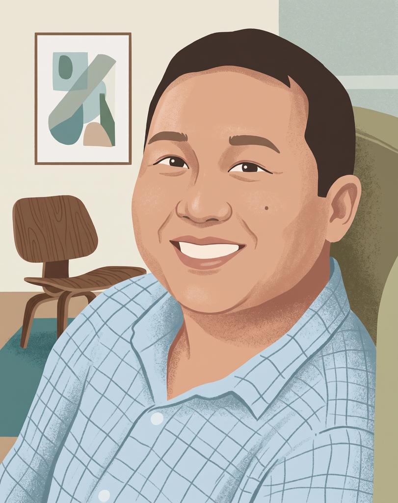

# Bhaswar Chakma

Welcome to my page! I am Bhaswar Chakma. This site brings together information about my academic background, professional experience, research interests, and selected research work.

## Education

ISCTE – Instituto Universitário de Lisboa

PhD in Economics | 2024 - present

University of Évora

Master in Statistical Modelling and Data Analysis | 2014 - 2017

Monash University

Bachelor of Business and Commerce, Economics | 2010 - 2012

## Experience

NielsenIQ

Data Scientist, Product Design & Enhancement | Oct 2025 - present

NielsenIQ

Analyst, Statistical Operations | May 2023 - Sep 2025

NielsenIQ

Analyst, Input Validation | Oct 2021 - Apr 2023

Católica Lisbon School of Business & Economics

Teaching Assistant | Feb 2020 - Jul 2021

University of Évora

Research Fellow | Feb 2020 - May 2021

IESE Business School, Universidad de Navarra

Collaborator | Nov 2019 - Mar 2020

CUBE, Católica Lisbon School of Business & Economics

Research Fellow | Nov 2017 - Oct 2019

## Research Interests

Applied econometrics, macroeconomics, and machine learning.

## Publication

Chakma, B., Gomes, D., Filipe, P. A., et al.  
“A temporal analysis on patient and health service delays in pulmonary tuberculosis in Portugal: inter and intra-regional differences and in(equalities) between gender and age.”  
*BMC Public Health*, 22, 1830, 2022.

https://doi.org/10.1186/s12889-022-14216-3

© Bhaswar Chakma

[GitHub](https://github.com/bhaswar-chakma)